# Part II - (Loan Data From Prosper)

## by (Muhsin Hameed)

## Investigation Overview

> **Loan Data From Prosper** explores about 114,000 persons who applied for loan, got it or not, and some variables around it. This investigation primarily examines some relationships between some of the variables such as Borrowers APR which is the Borrower's Annual Percentage Rate, Borrower's Rate, whether Borrowers are Home Owners and a few categorization of Borrowers based on Prosper rating.

## Dataset Overview

> The main data set contain 113937 row and 81 columns. All the columns ain't essential for this analysis, for that reason I would be working with 113937 row and 15 column. The details of the columns are below:

> ✔ ListingNumber: The number that uniquely identifies the listing to the public as displayed on the website.

> ✔ Term: The length of the loan expressed in months.

> ✔ LoanStatus: The current status of the loan: **Cancelled, Chargedoff, Completed, Current, Defaulted,**

> ✔ FinalPaymentInProgress, PastDue. The PastDue status will be accompanied by a delinquency bucket.

> ✔ BorrowerAPR: The Borrower's Annual Percentage Rate (APR) for the loan.

> ✔ BorrowerRate: The Borrower's interest rate for this loan.

> ✔ ProsperRating: The Prosper Rating assigned at the time the listing was created between AA - HR. Applicable for loans originated after July 2009.

> ✔ ProsperScore: A custom risk score built using historical Prosper data. The score ranges from 1-10, with 10 being the best, or lowest risk score. Applicable for loans originated after July 2009.

> ✔ BorrowerState: The two letter abbreviation of the state of the address of the borrower at the time the Listing was created.

> ✔ Occupation: The Occupation selected by the Borrower at the time they created the listing.

> ✔ EmploymentStatus:The employment status of the borrower at the time they posted the listing.

> ✔ IsBorrowerHomeOwner: A Borrower will be classified as a home-owner if they have a mortgage on their credit profile or provide documentation confirming they are a home-owner.

> ✔ IncomeRange: The income range of the borrower at the time the listing was created.

> ✔ LoanOriginalAmount: The origination amount of the loan.

> ✔ LoanOriginationDate: The date the loan was originated.

> ✔ Listing_Category: The category of the listing that the borrower selected when posting their listing

## (Visualization 1)

### Do Prosper Rating and Prosper Score affect Borrower APR ?

> The box plot shows an inverse relationship, which means the APR is significant to have a good rating and proper score

[figure not shown]

## (Visualization 2)

### How does the Borrower APR affect loan and HomeOwnership?

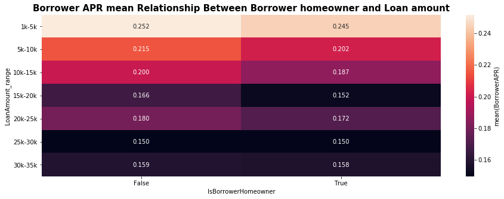